```r
# 0. Setup ----
required_pkgs <- c("readr","dplyr","ggplot2","GGally","corrplot",
                   "car","MASS","gridExtra","scales")
missing_pkgs <- required_pkgs[!(required_pkgs %in% installed.packages()[,"Package"])]
if (length(missing_pkgs)) {
  install.packages(missing_pkgs, repos = "https://cloud.r-project.org")
}
library(readr); library(dplyr); library(ggplot2); library(GGally); library(corrplot)
library(car); library(MASS); library(gridExtra); library(scales)
knitr::opts_chunk$set(echo = TRUE, message = FALSE, warning = FALSE)
data_path <- "ENB.txt"
```

```r
# 1. Read data ----
raw <- read_table2(data_path, col_names = FALSE, skip = 1, progress = FALSE)
is_num_col <- sapply(raw, is.numeric)
df_num <- raw[, is_num_col]
if (ncol(df_num) > 6) {
  df_num <- df_num[ , (ncol(df_num)-5):ncol(df_num)]
}
colnames(df_num) <- c("X1","X2","X3","X4","X5","Y")
df <- as.data.frame(df_num)
dim(df)
```

```
## [1] 19734     6
```

```r
head(df)
```

|  | X1 | X2 | X3 | X4 | X5 | Y |
| --- | --- | --- | --- | --- | --- | --- |
| 1 | 19.2 | 44.72250 | 19.00000 | 45.99250 | 733.6 | 60 |
| 2 | 19.2 | 44.62667 | 18.92667 | 45.89000 | 733.7 | 50 |
| 3 | 19.2 | 44.59000 | 18.89000 | 45.72333 | 733.8 | 50 |
| 4 | 19.2 | 44.53000 | 18.89000 | 45.53000 | 733.9 | 60 |
| 5 | 19.2 | 44.50000 | 18.89000 | 45.73000 | 734.0 | 50 |
| 6 | 19.2 | 44.50000 | 18.89000 | 45.79000 | 734.1 | 60 |

# Statistical Summary

```r
# 2. Basic summary / missing values / types ----
summary_stats <- summary(df)
summary_stats
```

```
##        X1              X2              X3              X4
##  Min.   :16.10   Min.   :20.46   Min.   :15.10   Min.   :27.66
##  1st Qu.:18.79   1st Qu.:37.90   1st Qu.:19.53   1st Qu.:35.53
##  Median :20.00   Median :40.50   Median :20.67   Median :38.40
##  Mean   :20.34   Mean   :40.42   Mean   :20.86   Mean   :39.03
##  3rd Qu.:21.50   3rd Qu.:43.26   3rd Qu.:22.10   3rd Qu.:42.16
##  Max.   :29.86   Max.   :56.03   Max.   :26.20   Max.   :51.09
##        X5              Y
##  Min.   :729.3   Min.   :  10.0
##  1st Qu.:750.9   1st Qu.:  50.0
##  Median :756.1   Median :  60.0
##  Mean   :755.5   Mean   :  97.7
##  3rd Qu.:760.9   3rd Qu.: 100.0
##  Max.   :772.3   Max.   :1080.0
```

```r
#sapply(df, function(x) sum(is.na(x)))
```

# Exploratory Data Analysis

## Univariate Analysis :

### Histogram and Boxplot

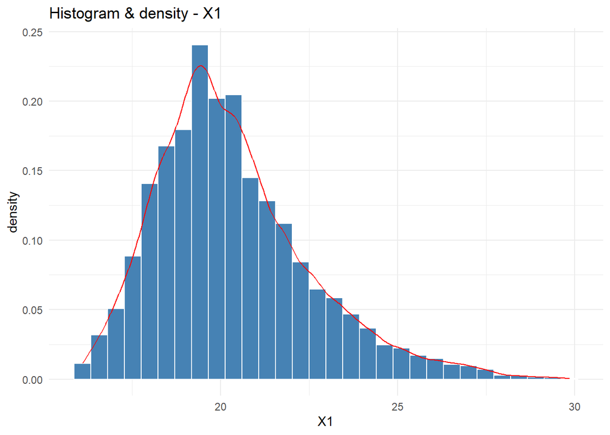

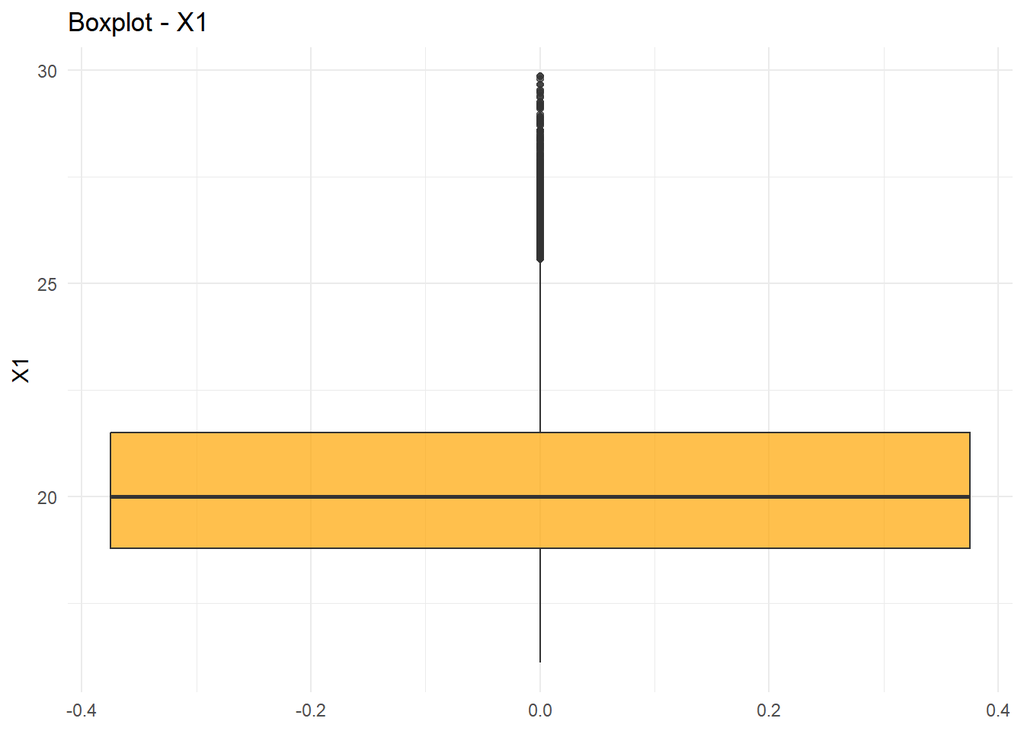

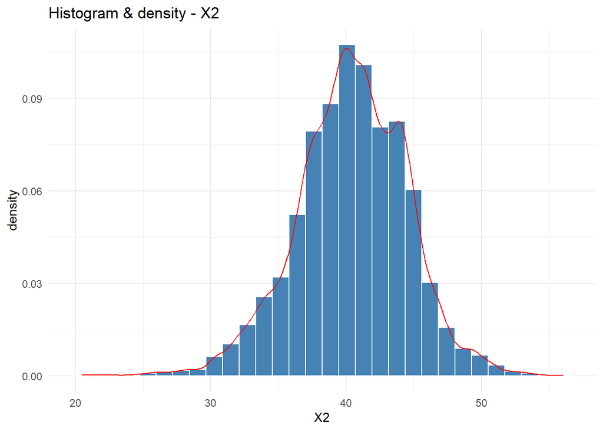

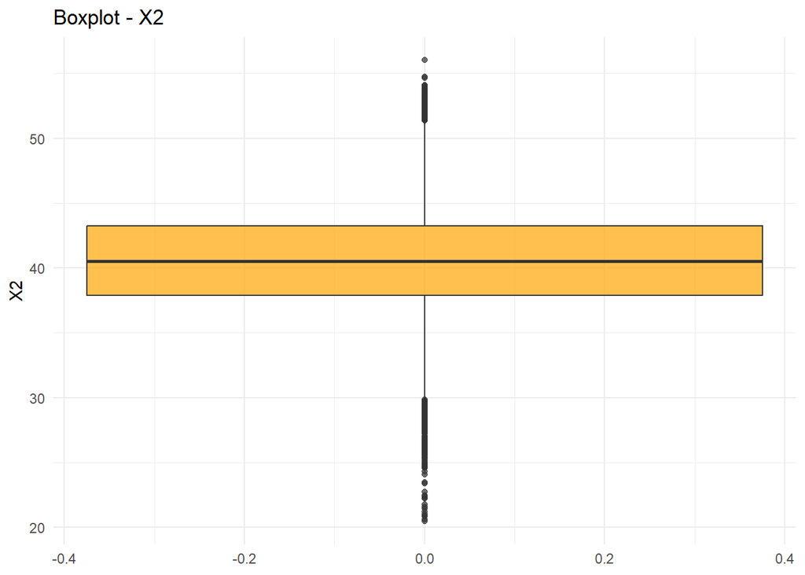

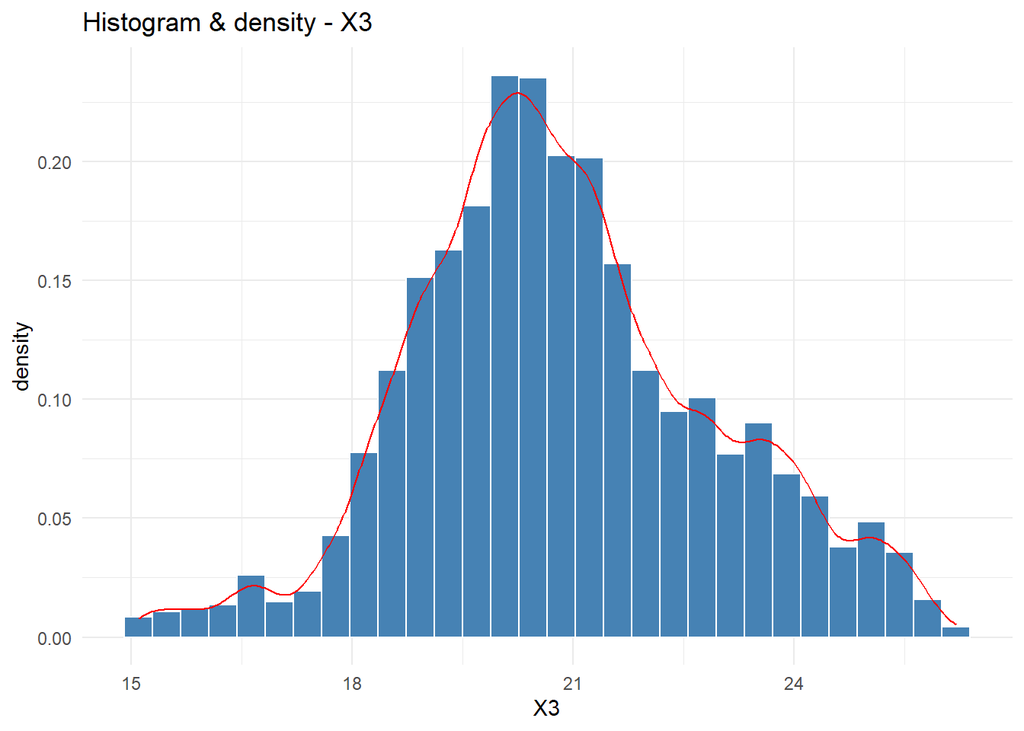

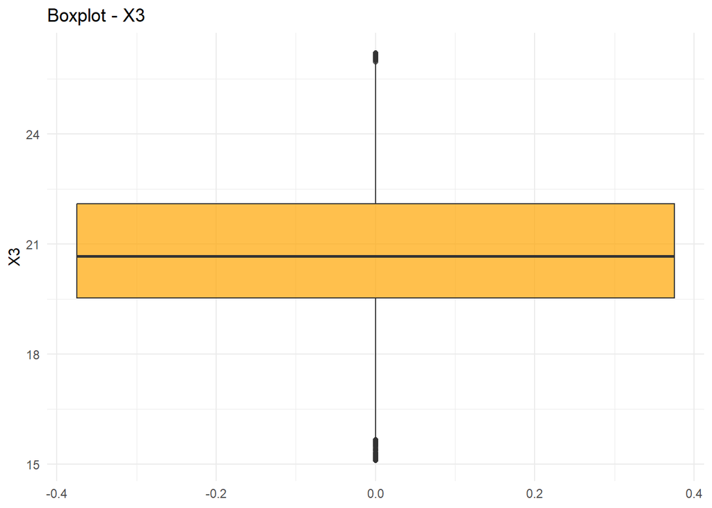

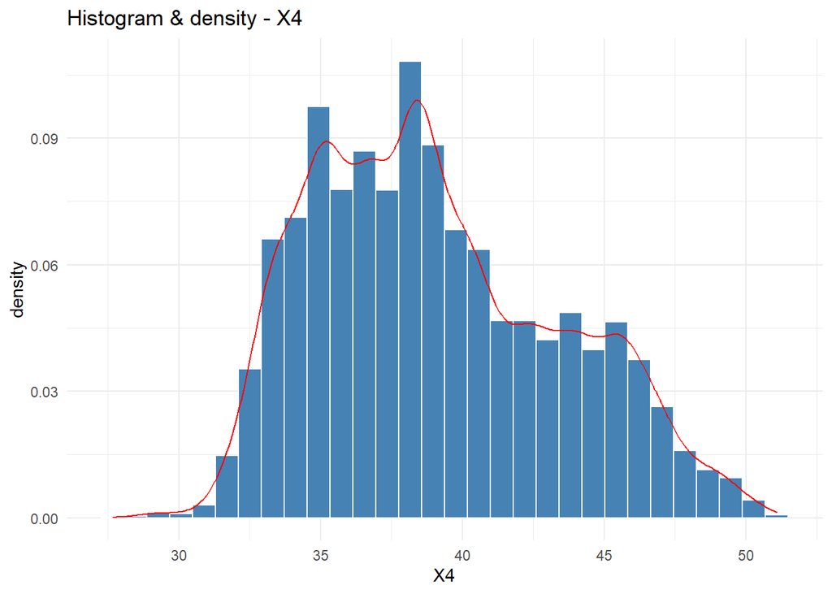

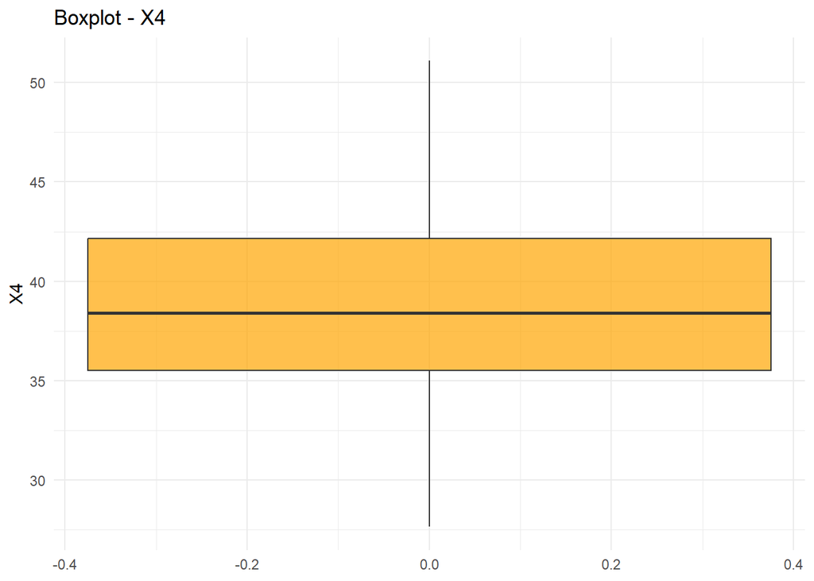

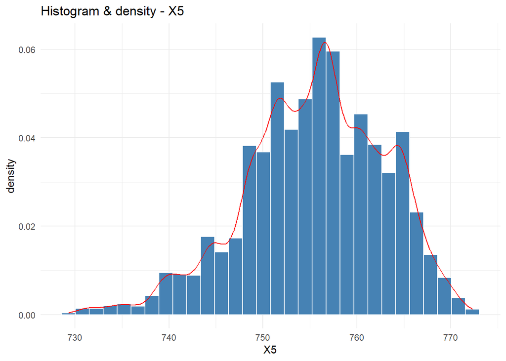

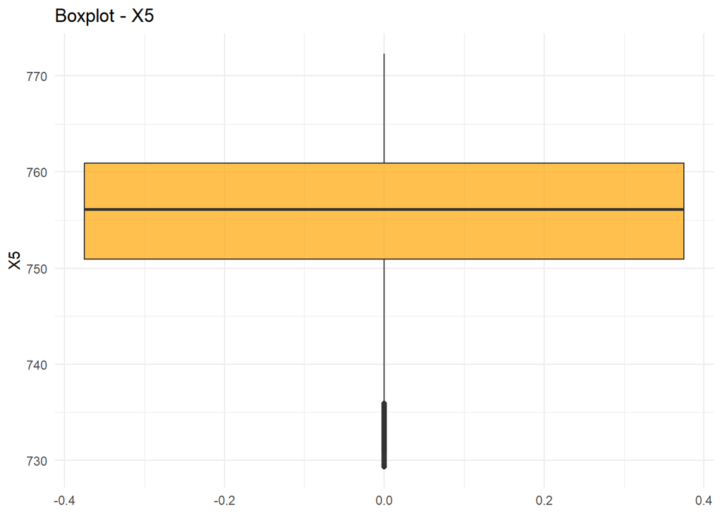

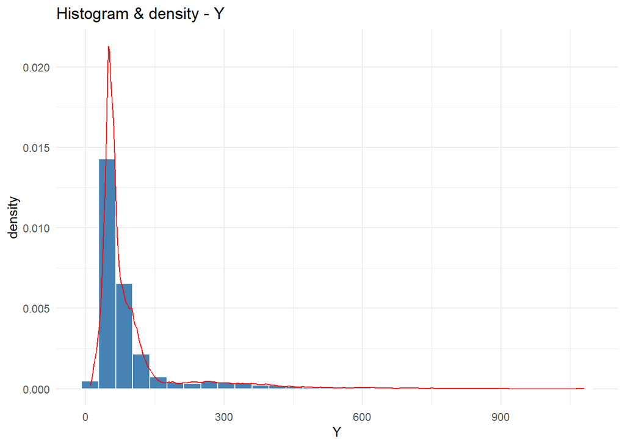

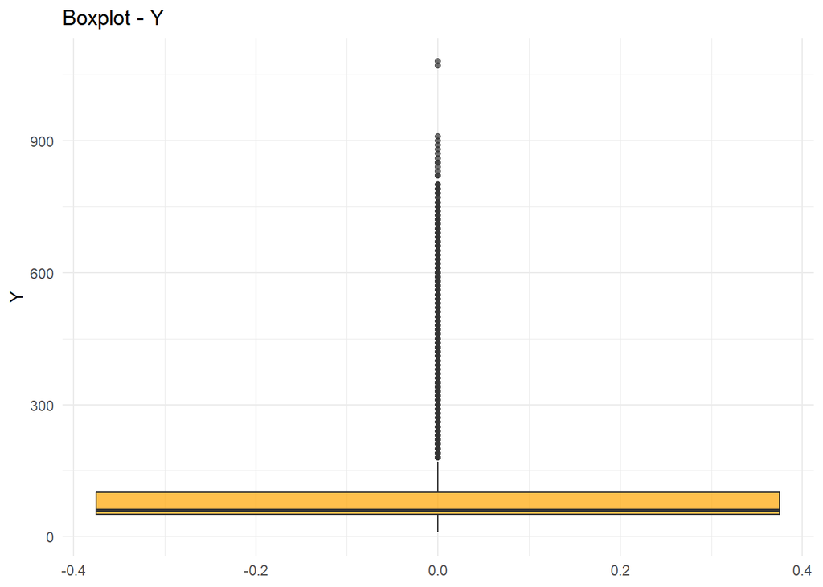

```r
# 3. Univariate plots (distribution) ----
plot_list <- list()
for (v in names(df)) {
  p_hist <- ggplot(df, aes_string(x = v)) +
    geom_histogram(aes(y = ..density..), bins = 30, fill = "steelblue", color = "white") +
    geom_density(alpha = 0.3, color = "red") +
    labs(title = paste("Histogram & density -", v)) +
    theme_minimal()
  p_box <- ggplot(df, aes_string(y = v)) +
    geom_boxplot(fill = "orange", alpha = 0.7) +
    labs(title = paste("Boxplot -", v)) +
    theme_minimal()
  plot_list[[paste0(v,"_hist")]] <- p_hist
  plot_list[[paste0(v,"_box")]] <- p_box
  print(p_hist)
  print(p_box)
}
```

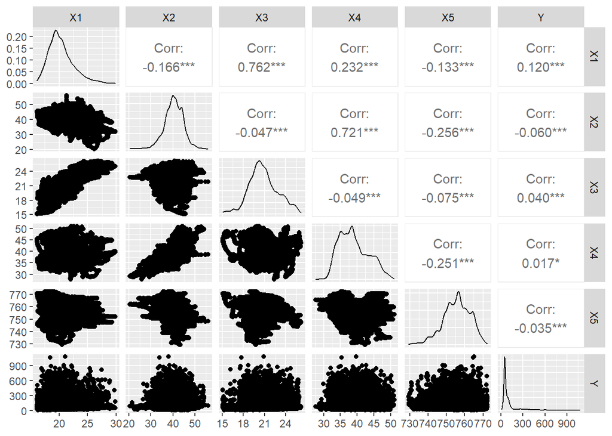

```r
# 4. Pairwise relationships ----
GGally::ggpairs(df, columns = 1:6, progress = FALSE)
```

## Bivariate Analysis :

### Scatter Plots with regression lines

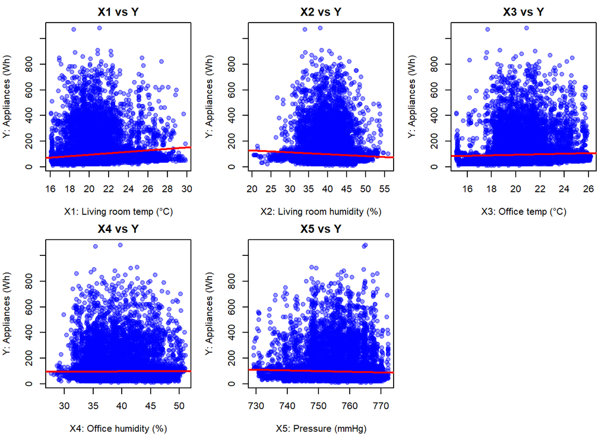

```r
# Choose the source matrix
src <- df  # or use the.data

# If there is a leading index column, drop it
if (ncol(src) == 7) src <- src[, 2:7, drop = FALSE]

# Ensure column names exist; assign if needed
if (is.null(colnames(src)) || !all(colnames(src) %in% c("X1","X2","X3","X4","X5","Y"))) {
  colnames(src) <- c("X1","X2","X3","X4","X5","Y")
}

# Set a 2x3 layout for five plots
op <- par(mfrow = c(2, 3), mar = c(4, 4, 2, 1))

plot(src[,"X1"], src[,"Y"], xlab = "X1: Living room temp (°C)", ylab = "Y: Appliances (Wh)",
     pch = 19, col = rgb(0,0,1,0.4), main = "X1 vs Y")
abline(lm(Y ~ X1, data = as.data.frame(src)), col = "red", lwd = 2)

plot(src[,"X2"], src[,"Y"], xlab = "X2: Living room humidity (%)", ylab = "Y: Appliances (Wh)",
     pch = 19, col = rgb(0,0,1,0.4), main = "X2 vs Y")
abline(lm(Y ~ X2, data = as.data.frame(src)), col = "red", lwd = 2)

plot(src[,"X3"], src[,"Y"], xlab = "X3: Office temp (°C)", ylab = "Y: Appliances (Wh)",
     pch = 19, col = rgb(0,0,1,0.4), main = "X3 vs Y")
abline(lm(Y ~ X3, data = as.data.frame(src)), col = "red", lwd = 2)

plot(src[,"X4"], src[,"Y"], xlab = "X4: Office humidity (%)", ylab = "Y: Appliances (Wh)",
     pch = 19, col = rgb(0,0,1,0.4), main = "X4 vs Y")
abline(lm(Y ~ X4, data = as.data.frame(src)), col = "red", lwd = 2)

plot(src[,"X5"], src[,"Y"], xlab = "X5: Pressure (mmHg)", ylab = "Y: Appliances (Wh)",
     pch = 19, col = rgb(0,0,1,0.4), main = "X5 vs Y")
abline(lm(Y ~ X5, data = as.data.frame(src)), col = "red", lwd = 2)

par(op)
```

Variables X1 and X3 show positive linear relationships with Y. Variables X2,X4 and X5 show weak or non linear relationships with Y.

## Correlation Analysis :

```r
# 5. Correlation matrix ----
cor_mat <- cor(df, use = "pairwise.complete.obs")
round(cor_mat, 3)
```

```
##        X1     X2     X3     X4     X5      Y
## X1  1.000 -0.166  0.762  0.232 -0.133  0.120
## X2 -0.166  1.000 -0.047  0.721 -0.256 -0.060
## X3  0.762 -0.047  1.000 -0.049 -0.075  0.040
## X4  0.232  0.721 -0.049  1.000 -0.251  0.017
## X5 -0.133 -0.256 -0.075 -0.251  1.000 -0.035
## Y   0.120 -0.060  0.040  0.017 -0.035  1.000
```

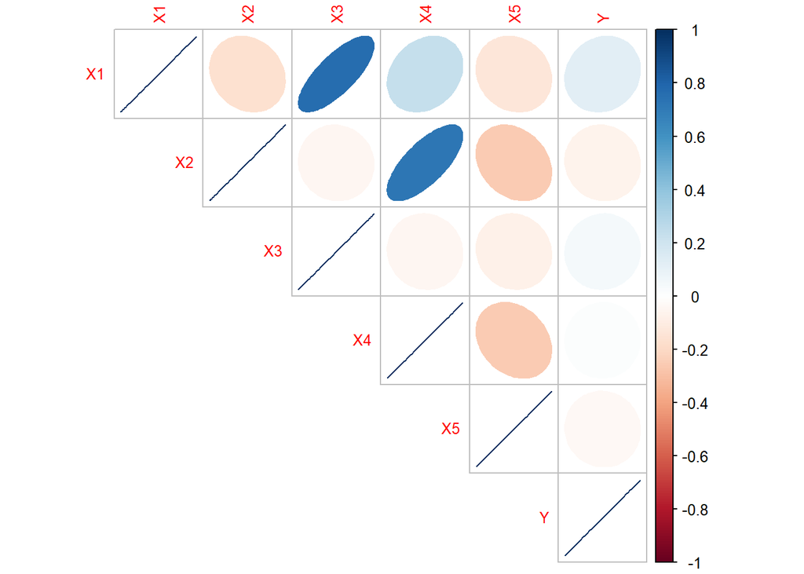

```r
corrplot::corrplot(cor_mat, method = "ellipse", type = "upper", tl.cex = 0.8)
```

Correlations:

- Strong positive correlation between X1 and X3
- Strong positive correlation between X2 and X4
- Moderate negative correlation between X2 and X5
- Moderate negative correlation between X4 and X5

```r
# 6. Multicollinearity checks ----
X <- as.matrix(df[, c("X1","X2","X3","X4","X5")])
eigs <- eigen(cor(X))
cond_number <- sqrt(max(eigs$values) / min(eigs$values))
cond_number
```

```
## [1] 6.541744
```

```r
lm_full <- lm(Y ~ X1 + X2 + X3 + X4 + X5, data = as.data.frame(df_num))
vifs <- car::vif(lm_full)
vifs
```

```
##       X1       X2       X3       X4       X5
## 7.980752 5.849774 5.635613 6.552831 1.122137
```

The condition number is 6.542, indicating weak multicollinearity overall in the entire model.. VIF > 5 already indicates moderate multicollinearity with X1,X2,X3,X4 individually. This also translates to being strong correlations observed earlier then predictors are almost linearly dependent. This will cause instability in coefficient estimates and large standard errors. Also model may being sensitive to small changes in data. Also Variables X1 and X3 show positive linear relationships with Y. Variables X2,X4 and X5 show weak or non linear relationships with Y. Appropriate Transformations are applied next to reduce multicollinearity and improve model stability.

# Sample the data and aggregation

1. Address skewness by appropriate transformation
2. Fit aggregation models : Linear programming is performed to find weights of predictor variables. lpSolve library used (source: AggWaFit718.R) to obtain optimum weights for respective aggregation.

```r
set.seed(226156731)
```

```r
num_row<-650
```

#read a random sample of 650 rows from the data

```r
the.data <- as.matrix(read.table("ENB.txt"))
my.data <- the.data[sample(1:nrow(the.data),num_row), 2:7]
head(my.data)
```

```
##            V2       V3    V4      V5       V6  V7
## [1,] 20.70000 33.83333 22.89 32.9000 764.7000  50
## [2,] 16.20000 43.96667 15.19 43.2600 769.9333 130
## [3,] 19.10000 38.16333 20.29 35.7900 751.0000 130
## [4,] 20.85667 33.33333 20.89 34.5000 756.3750  50
## [5,] 19.53333 39.02667 19.50 37.1725 755.2000  50
## [6,] 19.73000 37.12667 20.29 36.5900 756.0667  90
```

```r
colnames(my.data)<- c("X1","X2","X3","X4","X5","Y")
head(my.data)
```

```
##            X1       X2    X3      X4       X5   Y
## [1,] 20.70000 33.83333 22.89 32.9000 764.7000  50
## [2,] 16.20000 43.96667 15.19 43.2600 769.9333 130
## [3,] 19.10000 38.16333 20.29 35.7900 751.0000 130
## [4,] 20.85667 33.33333 20.89 34.5000 756.3750  50
## [5,] 19.53333 39.02667 19.50 37.1725 755.2000  50
## [6,] 19.73000 37.12667 20.29 36.5900 756.0667  90
```

#min max normalization and z-score standardization functions

```r
# minmax normalisation
minmax <- function(x){
  (x - min(x))/(max(x)-min(x))
}

# z-score standardisation and scaling to unit interval
unit.z <- function(x){
  ((x-mean(x))/sd(x))
}
```

# Polynomial Transformations

⦁ Polynomial functions x<sup>n</sup> can have skewed distributions to look more like normal distributions.

⦁ For x<sup>n</sup> ; 0<n<1 can be used when there are fewer very high values (positive skew), while n > 1, when there are fewer very low values (negative skew). This transforms work well when the data is already on the unit interval (by applying min-max transformation).

Below is a practical, engineer style solution in R that mimics what you want (optimize over n), but using grid search or optimize() plus a normality criterion such as Shapiro–Wilk p value .

## 1. Define a normality score for a given n

Maximize Shapiro–Wilk pvalue of x<sup>n</sup> (higher p → closer to normal). It means, pick the exponent n that makes the transformed data x<sup>n</sup> look most like a sample from a normal distribution, according to the Shapiro–Wilk normality test.

#### What the Shapiro–Wilk pvalue tells you

⦁ The Shapiro–Wilk test checks the null hypothesis “the data come from a normal distribution.”

⦁ High pvalue (e.g. > 0.05): data are compatible with normality (no strong evidence against normal).

⦁ Low pvalue (e.g. < 0.05): data deviate from normality. So if you apply the test to the transformed data x<sup>n</sup> as shapiro.test(x<sup>n</sup>)$p.value, a larger pvalue means that particular power n ,makes the distribution of x<sup>n</sup> closer to normal (in the sense of this test). (2025)

## 2.Grid search over n∈[0,2]

For power transforms, a reasonable range is, e.g., n∈[0,2] or whatever makes sense for your data domain (ensuring x<sup>n</sup> is defined).

The idea is the grid is all candidate n, the score is the Shapiro pvalue for x<sup>n</sup>, and you choose the n that maximizes that score to make x<sup>n</sup> as close to normal as this test can detect.

#Grid search over with lambda values from 0 to 2 in steps of 0.05 with with Shapiro–Wilk test of normalization

```r
normality_score_sw <- function(x, n) {
  x_t <- x ^ n
  # Remove NAs just in case
  x_t <- x_t[is.finite(x_t)]
  # Need at least 3 distinct values for a sensible test
  if (length(unique(x_t)) < 3) return(NA_real_)
  shapiro.test(x_t)$p.value
}

find_n_shapiro <- function(x, n_grid = seq(0, 2, by = 0.05)) {
  scores <- sapply(n_grid, function(n) normality_score_sw(x, n))
  # Exclude NA scores
  valid  <- !is.na(scores)
  if (!any(valid)) stop("No valid n in the grid (all transforms constant or invalid).")
  best_i <- which.max(scores[valid])
  list(
    n_opt   = n_grid[valid][best_i],
    p_opt   = scores[valid][best_i],
    grid    = n_grid,
    scores  = scores
  )
}
```

## 3. Apply transformations

1. Apply polynomial transformation with optimal power scale of x by Shapiro–Wilk normality test.

```r
I <- c( 'X1', 'X2', 'X3', 'X4', 'X5','Y')
variables_to_transform <- my.data[,I]
head(variables_to_transform)
```

```
##            X1       X2    X3      X4       X5   Y
## [1,] 20.70000 33.83333 22.89 32.9000 764.7000  50
## [2,] 16.20000 43.96667 15.19 43.2600 769.9333 130
## [3,] 19.10000 38.16333 20.29 35.7900 751.0000 130
## [4,] 20.85667 33.33333 20.89 34.5000 756.3750  50
## [5,] 19.53333 39.02667 19.50 37.1725 755.2000  50
## [6,] 19.73000 37.12667 20.29 36.5900 756.0667  90
```

```r
res_swY=find_n_shapiro(variables_to_transform[,"Y"])
variables_to_transform[,"Y"]=variables_to_transform[,"Y"]^res_swY$n_opt
res_swX1=find_n_shapiro(variables_to_transform[,"X1"])
variables_to_transform[,"X1"]=variables_to_transform[,"X1"]^res_swX1$n_opt
res_swX2=find_n_shapiro(variables_to_transform[,"X2"])
variables_to_transform[,"X2"]=variables_to_transform[,"X2"]^res_swX2$n_opt
res_swX3=find_n_shapiro(variables_to_transform[,"X3"])
variables_to_transform[,"X3"]=variables_to_transform[,"X3"]^res_swX3$n_opt
res_swX4=find_n_shapiro(variables_to_transform[,"X4"])
variables_to_transform[,"X4"]=variables_to_transform[,"X4"]^res_swX4$n_opt
res_swX5=find_n_shapiro(variables_to_transform[,"X5"])
variables_to_transform[,"X5"]=variables_to_transform[,"X5"]^res_swX5$n_opt
head(variables_to_transform)
```

```
##            X1       X2       X3       X4       X5        Y
## [1,] 1.163586 474.6280 7.651908 1.190857 584766.1 1.216042
## [2,] 1.149412 750.6996 5.861551 1.207270 592797.3 1.275549
## [3,] 1.158915 585.9776 7.075112 1.195881 564001.0 1.275549
## [4,] 1.164025 462.4213 7.210410 1.193688 572103.1 1.216042
## [5,] 1.160216 609.3721 6.894813 1.198150 570327.0 1.216042
## [6,] 1.160797 558.4065 7.075112 1.197204 571636.8 1.252311
```

#### Table of power applied to variables

Powers applied to variables

| Variable | Power | p value of normality test |
| --- | --- | --- |
| X1 | 0.05 | 3.94e-07 |
| X2 | 1.75 | 0.07 |
| X3 | 0.65 | 5.35e-05 |
| X4 | 0.05 | 1.52e-09 |
| X5 | 2 | 6.11e-05 |
| Y | 0.05 | 6.11e-05 |

## Plots of transformed data

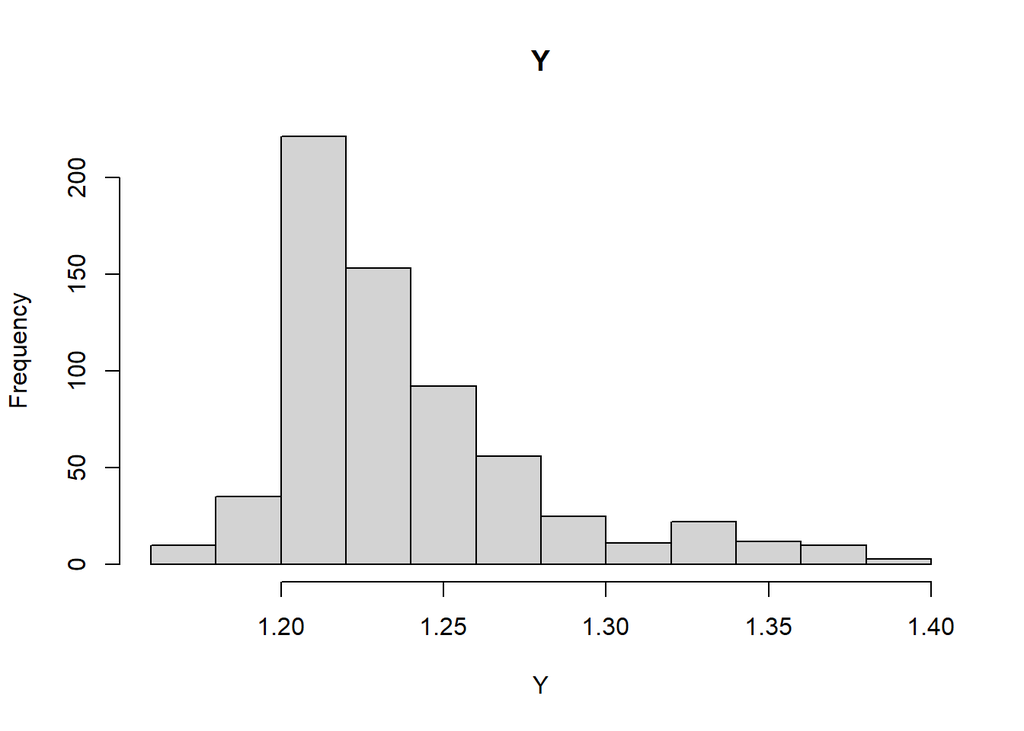

```r
hist(variables_to_transform[, "Y"], main = "Y", xlab = "Y")
```

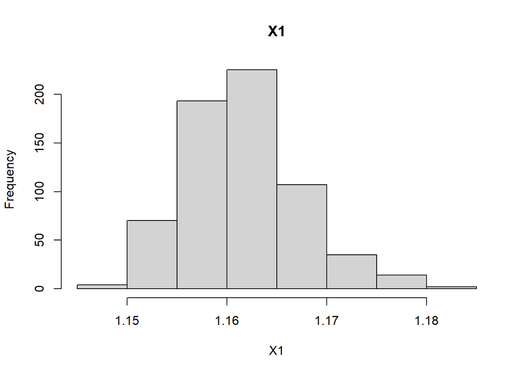

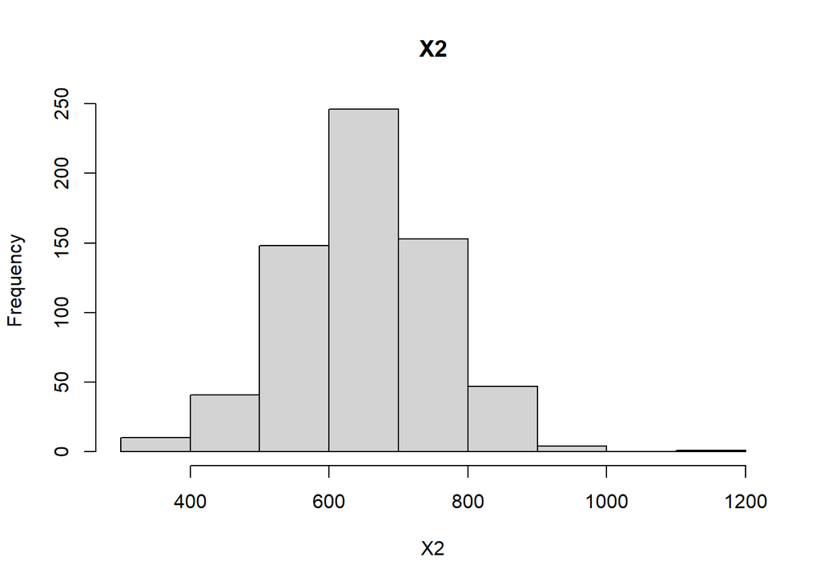

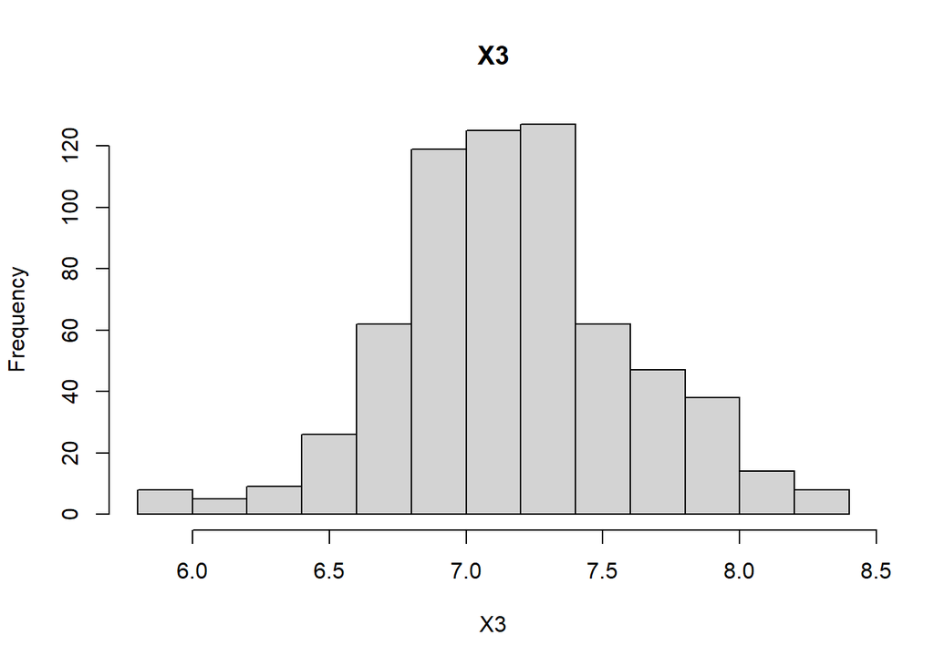

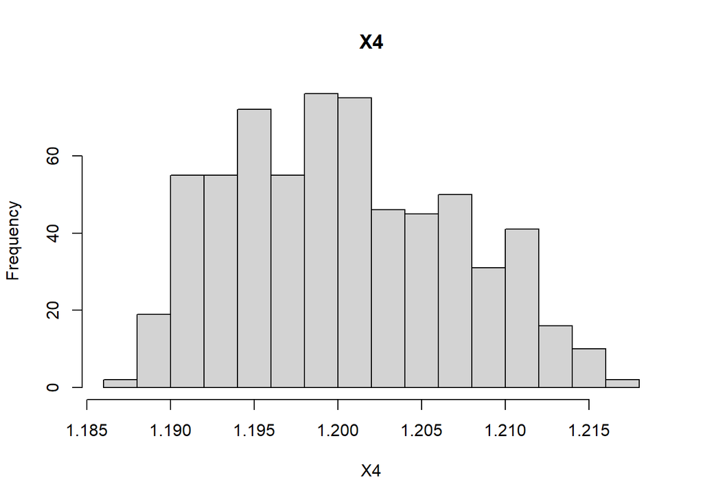

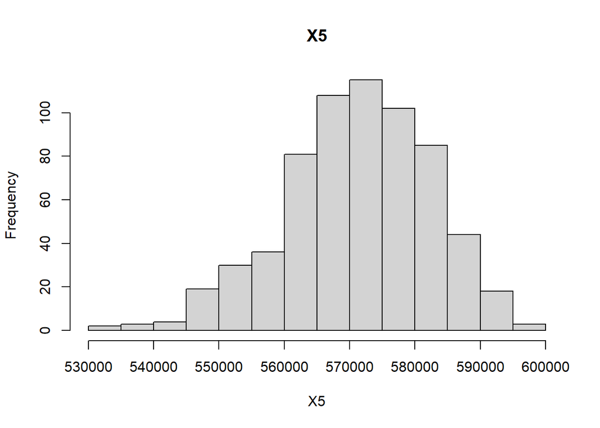

```r
for (k in paste0("X", 1:5)) { hist(variables_to_transform[, k], main = k, xlab = k) }
```